# ProyectDiamond

OmarG

February 18, 2021

```r
library(ggplot2)
library(dplyr)
data(diamonds)
summary(diamonds)
```

```
##      carat               cut        color        clarity          depth
##  Min.   :0.2000   Fair     : 1610   D: 6775   SI1    :13065   Min.   :43.00
##  1st Qu.:0.4000   Good     : 4906   E: 9797   VS2    :12258   1st Qu.:61.00
##  Median :0.7000   Very Good:12082   F: 9542   SI2    : 9194   Median :61.80
##  Mean   :0.7979   Premium  :13791   G:11292   VS1    : 8171   Mean   :61.75
##  3rd Qu.:1.0400   Ideal    :21551   H: 8304   VVS2   : 5066   3rd Qu.:62.50
##  Max.   :5.0100                     I: 5422   VVS1   : 3655   Max.   :79.00
##                                     J: 2808   (Other): 2531
##      table           price             x                y
##  Min.   :43.00   Min.   :  326   Min.   : 0.000   Min.   : 0.000
##  1st Qu.:56.00   1st Qu.:  950   1st Qu.: 4.710   1st Qu.: 4.720
##  Median :57.00   Median : 2401   Median : 5.700   Median : 5.710
##  Mean   :57.46   Mean   : 3933   Mean   : 5.731   Mean   : 5.735
##  3rd Qu.:59.00   3rd Qu.: 5324   3rd Qu.: 6.540   3rd Qu.: 6.540
##  Max.   :95.00   Max.   :18823   Max.   :10.740   Max.   :58.900
##
##        z
##  Min.   : 0.000
##  1st Qu.: 2.910
##  Median : 3.530
##  Mean   : 3.539
##  3rd Qu.: 4.040
##  Max.   :31.800
##
```

```r
dim(diamonds)
```

```
## [1] 53940    10
```

The order factor variable are cut, color, and clarity.

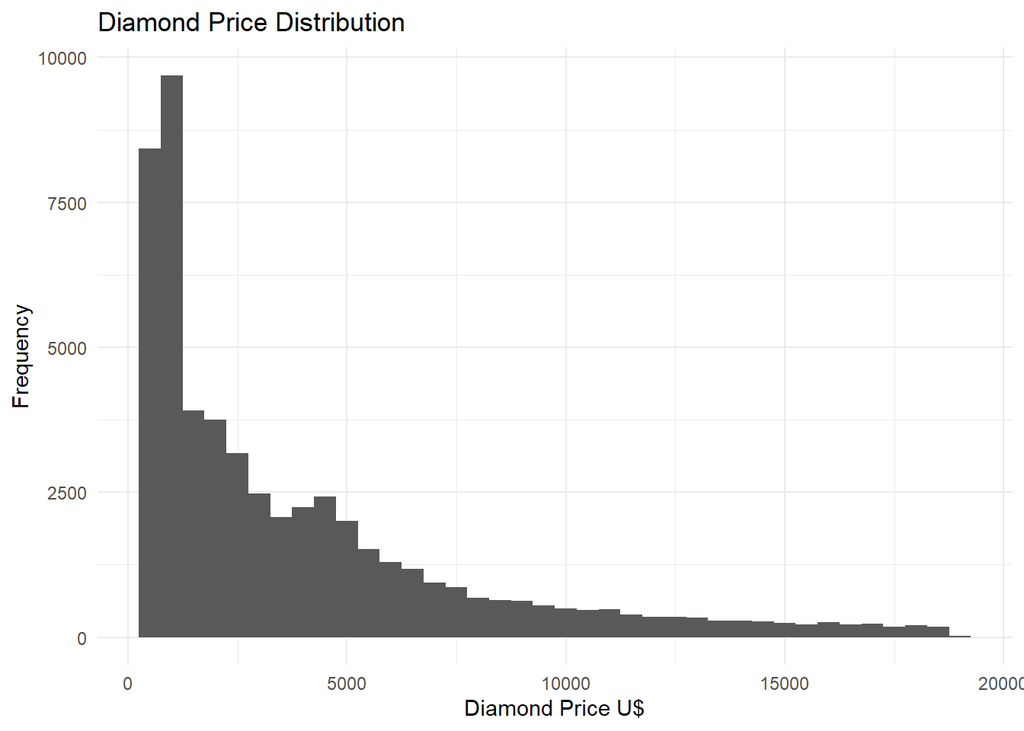

```r
ggplot(data=diamonds) + geom_histogram(binwidth=500, aes(x=diamonds$price)) + ggtitle("Diamond Price Distribution") + xlab("Diamond Price U$") + ylab("Frequency") + theme_minimal()
```

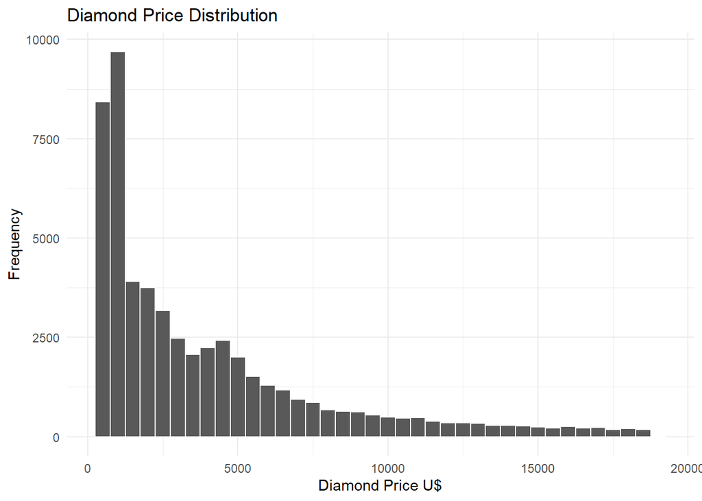

```r
ggplot(data = diamonds, mapping = aes(x =price)) + geom_histogram(binwidth = 500, color ="white") + ggtitle("Diamond Price Distribution") + xlab("Diamond Price U$") + ylab("Frequency") + theme_minimal()
```

This is a right skewed histogram, we can observe that most of the observations are below the 5000$ mark. Now lets take a look to the mean and median.

```r
diamonds %>% summarize(mean = mean(diamonds$price), median = median(diamonds$price))
```

```
## # A tibble: 1 x 2
##    mean median
##   <dbl>  <dbl>
## 1 3933.   2401
```

Now lets supposed we want to know the following:

```
-How many cost less than U$500?
-How many cost less than U$250?
-How many cost equal to U$15,000 or more?
```

```r
diamonds %>% summarize(less_than_250 = sum(diamonds$price < 250), less_than_500 = sum(diamonds$price < 500), more_than_15000 = sum(diamonds$price >= 15000),)
```

```
## # A tibble: 1 x 3
##   less_than_250 less_than_500 more_than_15000
##           <int>         <int>           <int>
## 1             0          1729            1656
```

# Let’s get closer to that peak

We have a very notorious peak in the histogram. So, let’s get close to observe it.

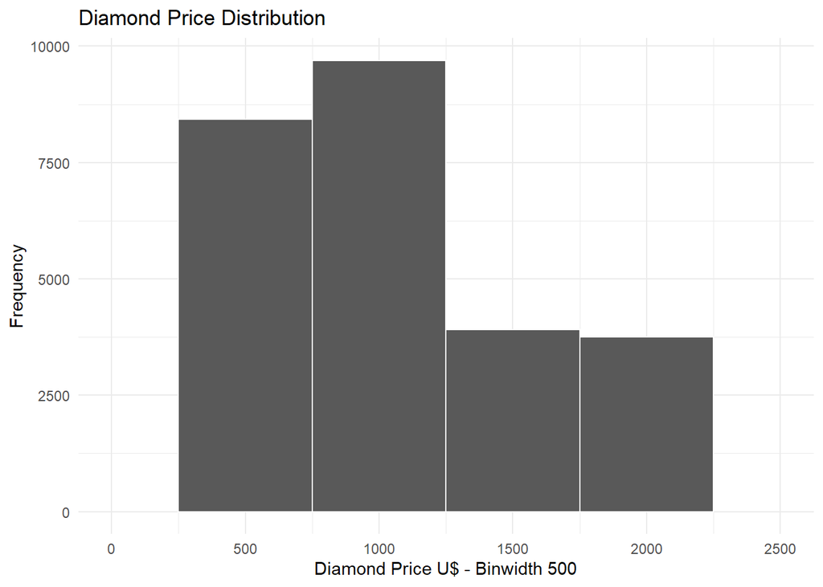

```r
ggplot(data = diamonds, mapping = aes(x = price)) + geom_histogram(binwidth = 500, color = "white") + ggtitle("Diamond Price Distribution") + xlab("Diamond Price U$ - Binwidth 500") + ylab("Frequency") + theme_minimal() + xlim(0,2500)
```

A little too square? The binwidth is definitively not the best, as we set it at 500 and put a limit of value to less than U$2,500. To solve this, we should lower the binwidth to see how that changes the picture:

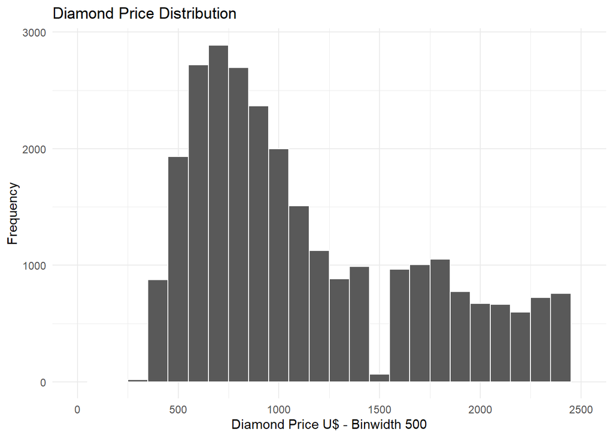

```r
ggplot(data = diamonds, mapping = aes(x = price)) + geom_histogram(binwidth = 100, color = "white") + ggtitle("Diamond Price Distribution") + xlab("Diamond Price U$ - Binwidth 500") + ylab("Frequency") + theme_minimal() + xlim(0,2500)
```

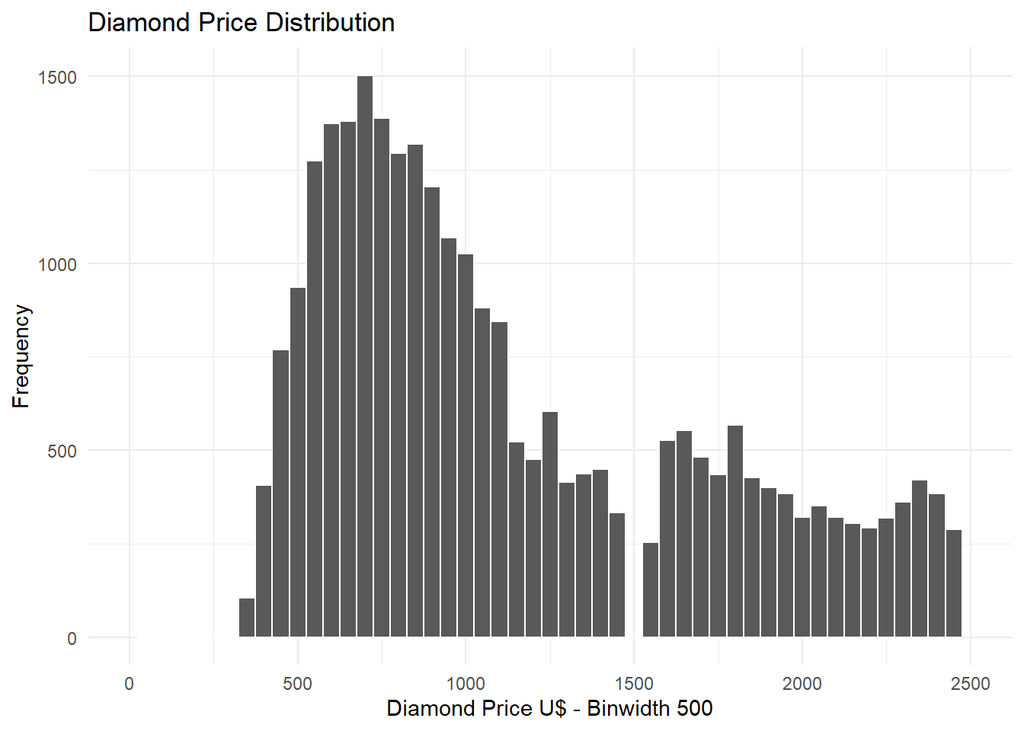

```r
ggplot(data = diamonds, mapping = aes(x = price)) + geom_histogram(binwidth = 50, color = "white") + ggtitle("Diamond Price Distribution") + xlab("Diamond Price U$ - Binwidth 500") + ylab("Frequency") + theme_minimal() + xlim(0,2500)
```

And we have another drop in frequency, this time it drooped to 1500. That is the reason Data Scientist are actual people and RStudio and R haven’t taken over! bin along with others functions will have a important role in the visualization of your graph

This is time to increase the challenge. What do you think about have five histograms, broken down by cut? That can sounds complicated, but this is not the case with R and ggplot2. Using the facet_wrap(~cut) command is almost too easy to produce the graphs:

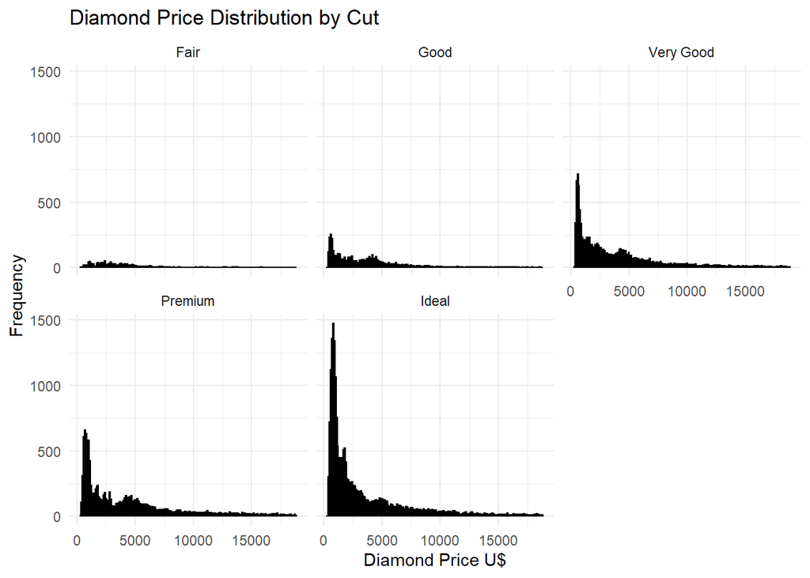

```r
ggplot(data=diamonds, mapping = aes(x = price)) + geom_histogram(binwidth=100, color="black") + ggtitle("Diamond Price Distribution by Cut") + xlab("Diamond Price U$") + ylab("Frequency") + theme_minimal() + facet_wrap(~cut)
```

Now that I see these graphs, I am wondering which is the highest and lowest priced diamond? This one is a little tricky, but the easiest way is to subset the diamonds data using as the filter the logical expression max(price) and min(price). It is unusual but it works.

```r
subset(diamonds, price == max(price))
```

```
## # A tibble: 1 x 10
##   carat cut     color clarity depth table price     x     y     z
##   <dbl> <ord>   <ord> <ord>   <dbl> <dbl> <int> <dbl> <dbl> <dbl>
## 1  2.29 Premium I     VS2      60.8    60 18823   8.5  8.47  5.16
```

```r
subset(diamonds, price == min(price))
```

```
## # A tibble: 2 x 10
##   carat cut     color clarity depth table price     x     y     z
##   <dbl> <ord>   <ord> <ord>   <dbl> <dbl> <int> <dbl> <dbl> <dbl>
## 1  0.23 Ideal   E     SI2      61.5    55   326  3.95  3.98  2.43
## 2  0.21 Premium E     SI1      59.8    61   326  3.89  3.84  2.31
```

And the answer for the first question is Premium cut for a diamond of 2.29 carat that sold at U18,823! Getting the cut of the lowest priced diamond is a similar task. And we have a tie for the lowest priced diamond, both sold at U326, one of 0.23 carat and Ideal cut, and another of 0.21 carats and Premium cut.

The last question is which cut has the lowest median price. This one is VERY tricky, since it involves lots of query in the data. The long and easy way is to use the which command to subset data vectors and then get the median of those:

```r
diamonds %>% group_by(cut) %>% summarize(median = median(price))
```

```
## # A tibble: 5 x 2
##   cut       median
## * <ord>      <dbl>
## 1 Fair       3282
## 2 Good       3050.
## 3 Very Good  2648
## 4 Premium    3185
## 5 Ideal      1810
```

Going back to our grid histogram, let’s get different frequency scales (the y axis) to accomodate for specific patterns. SOmetimes it is harder to see patterns if all five charts use the same scale for comparison and patterns become lost in the translation. The command is very easy.

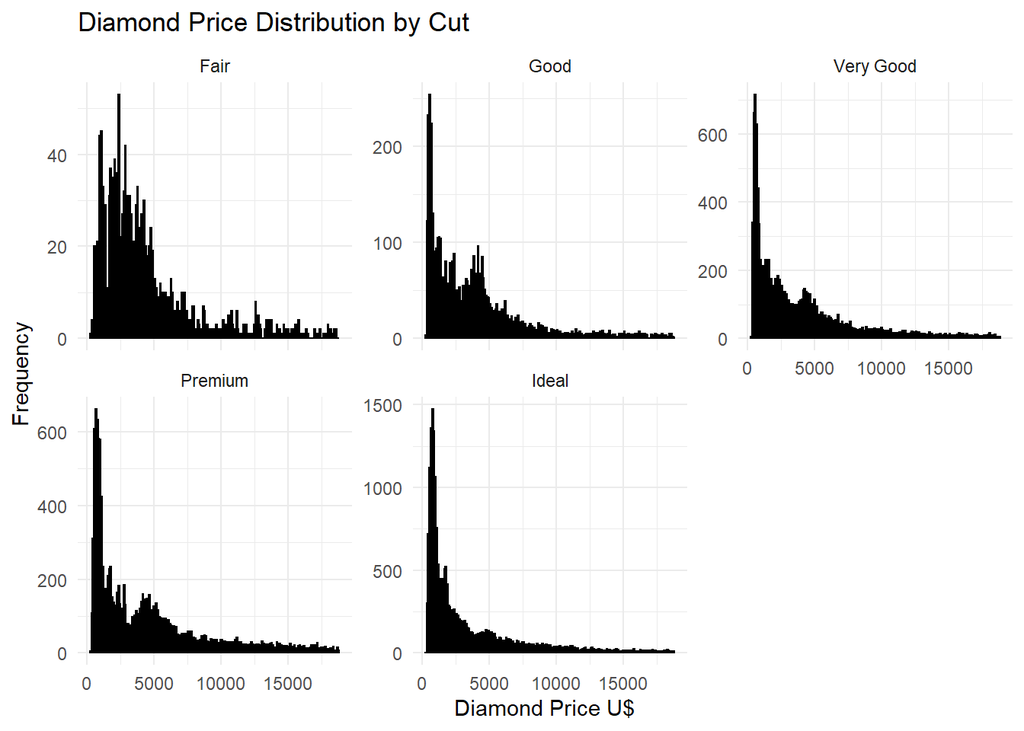

```r
ggplot(data = diamonds, mapping = aes(x = price)) + geom_histogram(binwidth=100, color="black") + ggtitle("Diamond Price Distribution by Cut") + xlab("Diamond Price U$") + ylab("Frequency") + theme_minimal() + facet_wrap(~cut, scales="free_y")
```

Let’s do another example, this time working on plotting price per carat of different cuts.

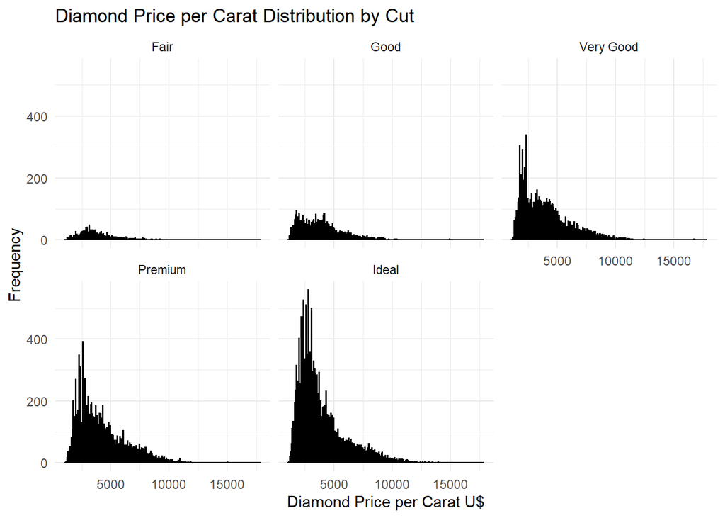

```r
ggplot(data=diamonds, mapping = aes(x = price/carat)) + geom_histogram(binwidth=50, color="black") + ggtitle("Diamond Price per Carat Distribution by Cut") + xlab("Diamond Price per Carat U$") + ylab("Frequency") + theme_minimal() + facet_wrap(~cut)
```

UDACITY also asks for log10 scale. Let’s work now on plotting price per carat of different cuts and using Log10.

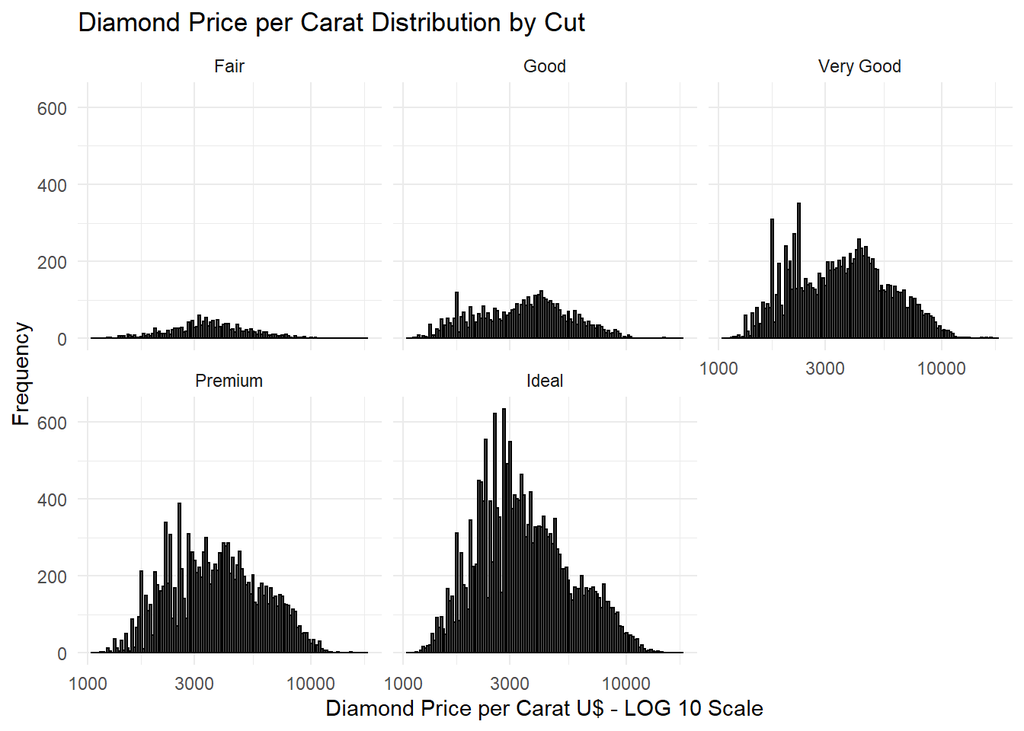

```r
ggplot(data=diamonds, mapping = aes(x = price/carat)) + geom_histogram(binwidth=0.01, color="black") + ggtitle("Diamond Price per Carat Distribution by Cut") + xlab("Diamond Price per Carat U$ - LOG 10 Scale") + ylab("Frequency") + theme_minimal() + facet_wrap(~cut) + scale_x_log10()
```